# Sesion_6

2026-05-12

# ¿Que tenemos hasta ahora?

En practicas pasadas habiamos definido dos modelos multivariables que predicen la nota final y el tiempo de uso del telefono para estudiantes. Luego corregimos las asunciones que hacian falta o decidimos que un modelo de regresion lineal no era lo sufientemente bueno para explicar nuestro modelo. A continuacion veremos si como podemos desarrollar nuestros modelos y si podemos utilizar otros modelos para explicar nuestras variables objetivos

# Distribuccion de nuestras variables objetivos

- Modelo prediccion nota

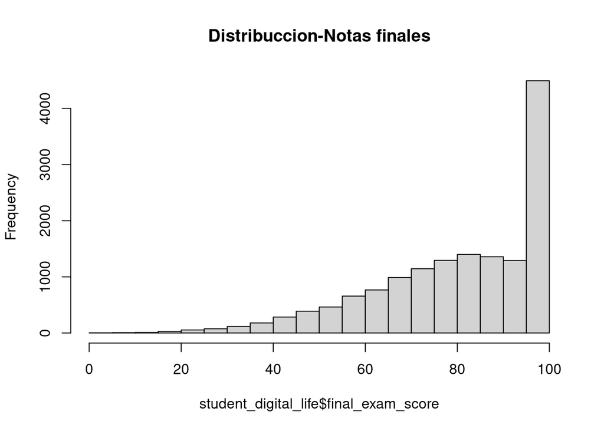

```r
hist(student_digital_life$final_exam_score, main="Distribuccion-Notas finales")
```

En la anterior sesión observamos que nuestro modelo de regresión lineal que predecía la variable nota final sufre de la falta de asunciones de linealidad, homocedasticidad y normalidad. La variable que tratamos de predecir tampoco sigue una distribuccion normal, si nos fijamos en la grafico hay una asimetria negativa. Desde la sesion pasada sabiamos que una regresion lineal no serviria en este caso. Estuvimos investigando tanto en internet como consultas a LMM’s sobre que podriamos hacer.

- Modelo prediccion smartphone

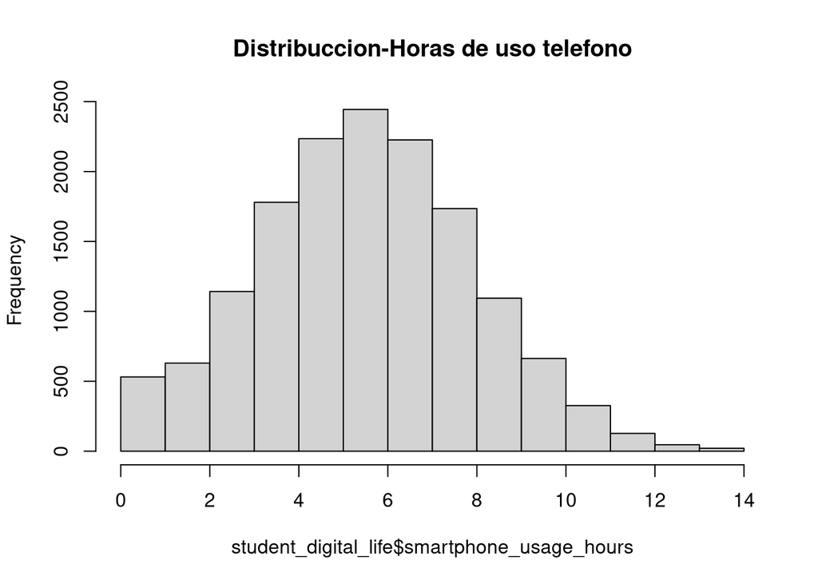

```r
hist(student_digital_life$ smartphone_usage_hours, main="Distribuccion-Horas de uso telefono")
```

Nuestro modelo actual tenia corregidas sus asunciones, no a la perfeccion pero corregimos lo mas que pudimos. Nuestra variable Y sigue una lo mas parecido a una distribuccion normal. Por lo que mantendremos nuestro modelo de regresion linel, pero corrigiendo ciertos detalles como aumentar el R^2 ajustado que vimos la practica pasada.

# Nuevos modelos

- GLM-Prediccion nota

Hemos decidido que para aplacar el problema usaremos una regresion logistica. Crearemos una nueva variable que se encargara de recolectar si un estudiante ha aprobado o no. Teniendo en cuenta un 50 como aprobado, notas mayores a 50 estaran aprovados caso contrario estaran suspendidas. Para este modelo seguiremos usando las mismas varaibles predictoras que teniamos antes mas nuevas adiciones.

```r
# Creamos la varaible aprobado
student_digital_life$aprobado <- ifelse(student_digital_life$final_exam_score >= 50, 1, 0)

student_digital_life$aprobado <- as.factor(student_digital_life$aprobado)
levels(student_digital_life$aprobado) <- c("Suspendido", "Aprobado") # 0 = Suspendido, 1 = Aprobado


# Construir el modelo
modelo_logistico_nota <- glm(aprobado ~ study_hours_per_day + gaming_hours + assignment_completion_percent + sleep_hours + motivation_level + class_attendance_percent, family = binomial(), data = student_digital_life)

report(modelo_logistico_nota)
```

```
##                               Estimate Std. Error exp(Estimate) Lower 95%
## (Intercept)                    -10.172      0.478             0         0
## study_hours_per_day              1.093      0.028         2.982     2.823
## gaming_hours                    -0.205      0.025         0.814     0.775
## assignment_completion_percent    0.041      0.003         1.041     1.036
## sleep_hours                      0.226      0.026         1.253     1.191
## motivation_level                 0.215      0.019          1.24     1.194
## class_attendance_percent         0.045      0.004         1.047     1.039
## AIC                           5014.063
##                               Upper 95% P-value
## (Intercept)                           0  <0.001
## study_hours_per_day               3.155  <0.001
## gaming_hours                      0.856  <0.001
## assignment_completion_percent     1.047  <0.001
## sleep_hours                       1.319  <0.001
## motivation_level                  1.288  <0.001
## class_attendance_percent          1.055  <0.001
## AIC
```

**Explicacion modelo**

**Metricas modelo**

```r
# Metricas, solo nos fijamos en el AIC
model_performance(modelo_logistico_nota)
```

```
## # Indices of model performance
##
## AIC    |   AICc |    BIC | Tjur's R2 |  RMSE | Sigma | Log_loss | Score_log |   PCP
## -----------------------------------------------------------------------------------
## 5014.1 | 5014.1 | 5067.4 |     0.302 | 0.224 |     1 |    0.167 |      -Inf | 0.902
```

```r
# AUC
probabilidades <- predict(modelo_logistico_nota, type = "response")

clases_predichas <- ifelse(probabilidades >= 0.5, 1, 0)


# Primero, necesitamos las probabilidades predichas por el modelo (entre 0 y 1)
probabilidades <- predict(modelo_logistico_nota, type = "response")

# Calcular la curva ROC y extraer el AUC
curva_roc <- roc(response = student_digital_life$aprobado, predictor = probabilidades, direction = "<")
auc(curva_roc)
```

```
## Area under the curve: 0.9208
```

Aparentemente tenemos un modelo perfecto, pero nos tenemos que fijar en una cosa. Al crear una nueva variable que clasifica si un estudiante a suspendido o ha aprobado no tenemos clases iguales.

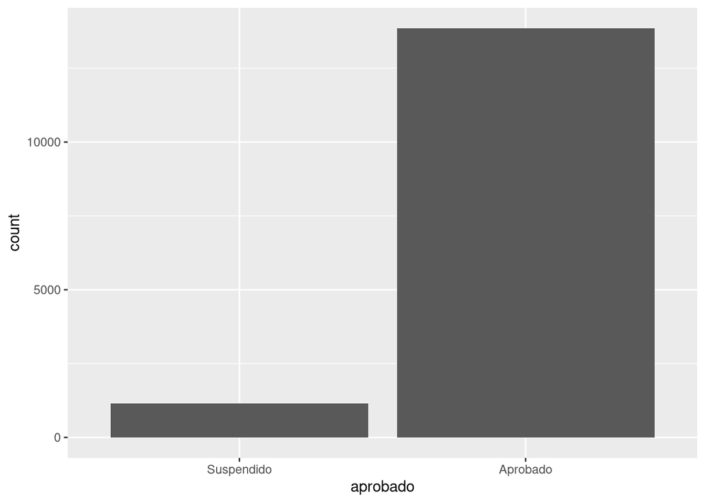

```r
ggplot(student_digital_life, aes(x=aprobado)) + geom_bar()
```

Tenemos un desequilibrio de clases, lo cual un resultado tan perfecto como un AUC de 0.92 indicaria que nuestro modelo tiene un sobreajuste. Este es el menor de nuestros problemas por que mas adelante podemos soloucionar esto, pero vayamos a ver si nuestro modelo cumple con las asunciones.

- LM-Prediccion smartphone

```r
modelo_multivariable_smart_corregido <- gls(smartphone_usage_hours ~ study_hours_per_day + assignment_completion_percent + exercise_hours + final_exam_score , data = student_digital_life, weights = varExp(form = ~ final_exam_score))

model_performance(modelo_multivariable_smart_corregido)
```

```
## # Indices of model performance
##
## AIC     |     BIC |    R2 |  RMSE | Sigma
## -----------------------------------------
## 68734.8 | 68788.1 | 0.037 | 2.392 | 2.240
```

```r
summary(modelo_multivariable_smart_corregido)
```

```
## Generalized least squares fit by REML
##   Model: smartphone_usage_hours ~ study_hours_per_day + assignment_completion_percent +      exercise_hours + final_exam_score
##   Data: student_digital_life
##        AIC      BIC    logLik
##   68776.43 68829.74 -34381.21
##
## Variance function:
##  Structure: Exponential of variance covariate
##  Formula: ~final_exam_score
##  Parameter estimates:
##        expon
## 0.0008153041
##
## Coefficients:
##                                   Value  Std.Error   t-value p-value
## (Intercept)                    6.643051 0.13163032  50.46748  0.0000
## study_hours_per_day            0.209963 0.01310677  16.01943  0.0000
## assignment_completion_percent  0.008028 0.00145036   5.53509  0.0000
## exercise_hours                 0.057194 0.02369239   2.41402  0.0158
## final_exam_score              -0.034791 0.00142475 -24.41895  0.0000
##
##  Correlation:
##                               (Intr) std___ assg__ exrcs_
## study_hours_per_day           -0.033
## assignment_completion_percent -0.730  0.165
## exercise_hours                -0.202  0.066  0.024
## final_exam_score              -0.324 -0.661 -0.259 -0.082
##
## Standardized residuals:
##          Min           Q1          Med           Q3          Max
## -2.897881684 -0.682895116  0.002240317  0.663668631  3.377897641
##
## Residual standard error: 2.239864
## Degrees of freedom: 15000 total; 14995 residual
```

Hemos intentado modificar nuestro modelo varias veces, usando distintas combinaciones de varaibles para ver si podiamos mejorar el rendimiento del mismo. Estos repetidos cambios no mejoraron el modelo si no que lo empeoraban. Usaremos una matriz de correlacion para ver si encontramos variables con relacion a las horas de smartphone

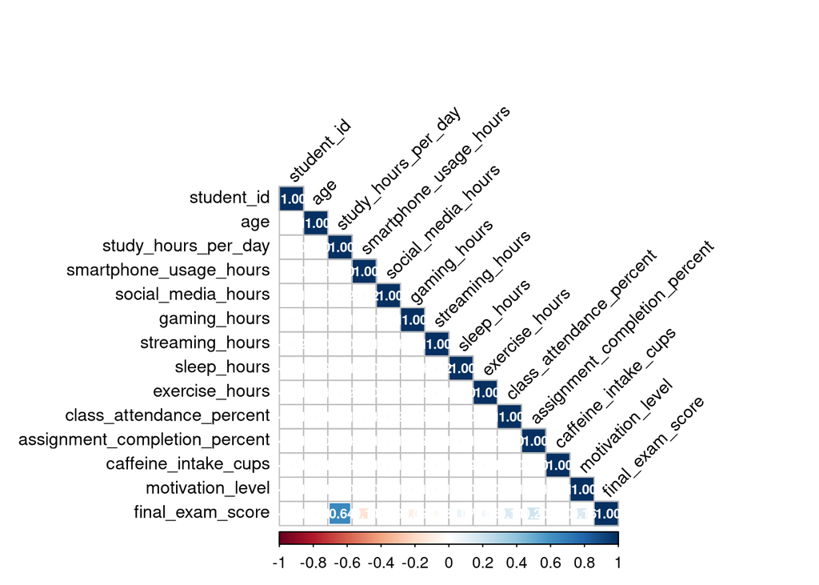

```r
# Matrizcorrelacion solo para variables numericas
datos_numericos <- student_digital_life[, sapply(student_digital_life, is.numeric)]
matriz_cor <- cor(datos_numericos)

corrplot(matriz_cor,
         method = "square",      # circle, square, ellipse, number, color
         type = "lower",         # full, upper, lower
         tl.col = "black",       # color de labels
         tl.srt = 45,            # rotación de labels
         addCoef.col = "white",  # agregar coeficientes
         number.cex = 0.7,       # tamaño de números
         tl.cex = 0.9,)           # tamaño de labels
```

Vemos el problema no solo esta en la varaible que buscamos si no que todas las varaibles no tienen casi relacion entre si, unicamente tiene relacion con la variable objetivo del problema final_exam. Descartaremos la posibilidad de realizar cualquier otro modelo que no tenga como objetivo la nota final. De todas formas mantendremos este modelo para hacer alguna que otra prediccion y ver como se comporta.

# Asunciones de modelo GLM

**Linealidad**

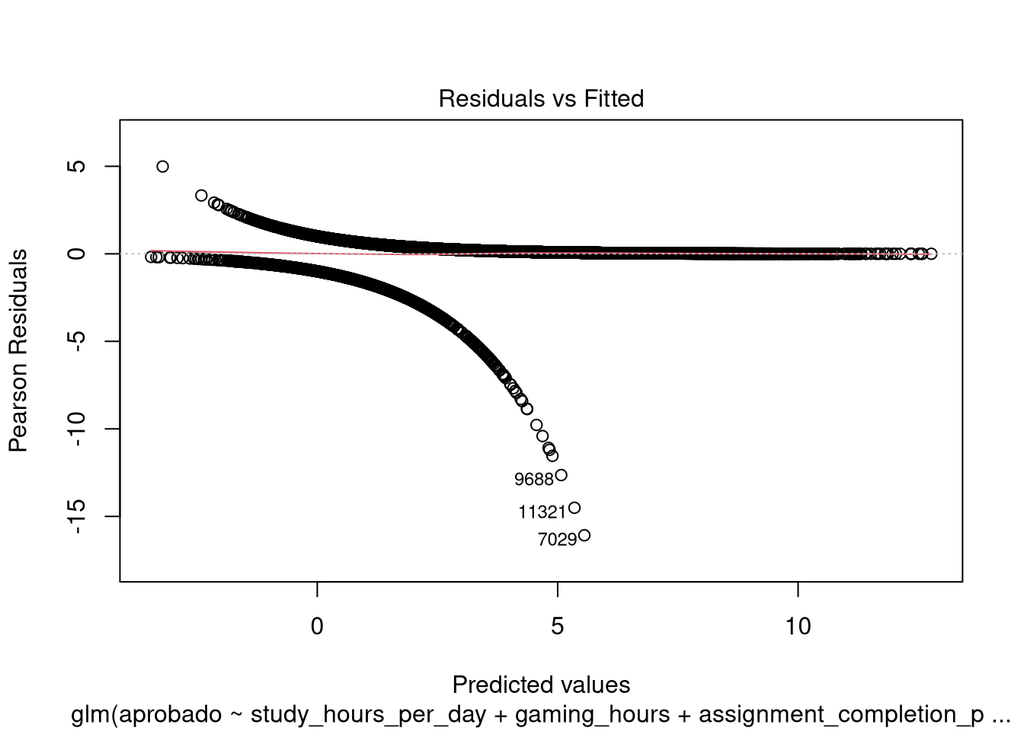

```r
plot(modelo_logistico_nota, which=1)
```

El grafico nos muestra que la recta esta lo suficientemente centrada en 0, y vemos como nuestros residuos de dispersan. Cumplimos la asuncion de linealidad.

**Sobredispersion**

```r
(sobredispersion <- check_overdispersion(modelo_logistico_nota))
```

```
## # Overdispersion test
##
##  dispersion ratio = 1.047
##           p-value = 0.064
```

```
## No overdispersion detected.
```

**Outliers influyentes**

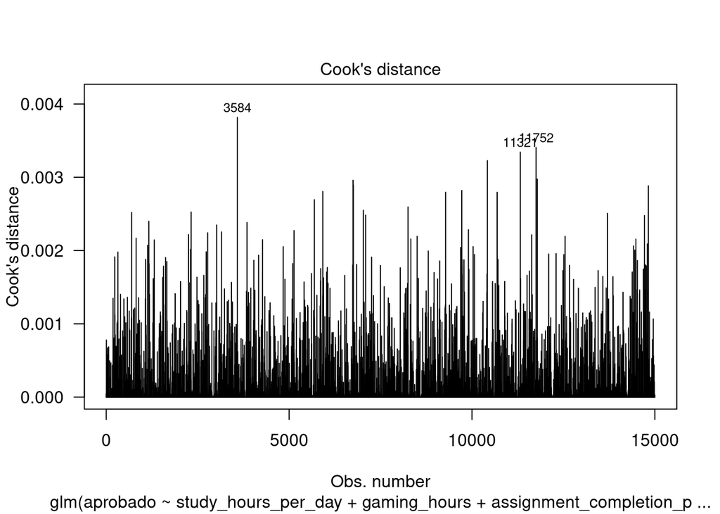

```r
plot(modelo_logistico_nota, which=4, las=1)
```

No tenemos outlier influyentes

**Multicolinealidad**

```r
vif(modelo_logistico_nota)
```

```
##           study_hours_per_day                  gaming_hours
##                      1.115746                      1.019545
## assignment_completion_percent                   sleep_hours
##                      1.044949                      1.013245
##              motivation_level      class_attendance_percent
##                      1.021886                      1.032772
```

Seguimos sin tener multicolinealidad

Nuestro modelo de regresion logistica cumple todas las asunciones, pero su unico defecto es que tenemos overfitting del modelo por el desbalance de las clases. Este problema lo solucionaremos mas adelante

#Error de la muestra con la población: Holdout, Validación cruzada, Bootstrap

## Modelos prediccion smartphone

**Método Holdout**

```r
#División Holdout (80% train, 20% test)
set.seed(123)
indice <- createDataPartition(student_digital_life$smartphone_usage_hours, p = 0.8, list = FALSE)
datos_train <- student_digital_life[indice, ]
datos_test  <- student_digital_life[-indice, ]

#Entrenamiento de los modelos con los datos de train

# Modelo Original (LM estándar)
mod_lm <- lm(smartphone_usage_hours ~ study_hours_per_day + streaming_hours +
             exercise_hours + final_exam_score, data = datos_train)

# Modelo Mejorado: correccion de heterocedasticidad
mod_gls <- gls(smartphone_usage_hours ~ study_hours_per_day + assignment_completion_percent +
               exercise_hours + final_exam_score,
               data = datos_train,
               weights = varExp(form = ~ final_exam_score))

# Predecir usando parte de test
pred_lm <- predict(mod_lm, newdata = datos_test)
pred_gls <- predict(mod_gls, newdata = datos_test)

# Calcular RMSE para ambos
rmse_holdout_lm  <- RMSE(pred = pred_lm, obs = datos_test$smartphone_usage_hours)
rmse_holdout_gls <- RMSE(pred = pred_gls, obs = datos_test$smartphone_usage_hours)

# Resultados
cat("--- Resultados Holdout ---\n")
```

```
## --- Resultados Holdout ---
```

```r
cat("Modelo Original (LM)  - RMSE:", round(rmse_holdout_lm, 4), "\n")
```

```
## Modelo Original (LM)  - RMSE: 2.3789
```

```r
cat("Modelo Mejorado (GLS) - RMSE:", round(rmse_holdout_gls, 4), "\n")
```

```
## Modelo Mejorado (GLS) - RMSE: 2.3813
```

**Cross-Validation con k=20**

```r
set.seed(123)
folds <- createFolds(student_digital_life$smartphone_usage_hours, k = 20, list = TRUE, returnTrain = TRUE)
control_cv <- trainControl(method = "cv", number = 20)

# LM Entrenamiento
modelo_lm_cv <- train(
  smartphone_usage_hours ~ study_hours_per_day + streaming_hours + exercise_hours + final_exam_score,
  data = student_digital_life,
  method = "lm",
  trControl = control_cv
)

# Extraer RMSE promedio
rmse_cv_lm <- modelo_lm_cv$results$RMSE



# GLS Entrenamiento

rmse_gls_vec <- numeric(10) # Vector para guardar el RMSE de cada fold

for(i in 1:10) {

  train_i <- student_digital_life[folds[[i]], ]
  test_i  <- student_digital_life[-folds[[i]], ]

  mod_gls_i <- gls(smartphone_usage_hours ~ study_hours_per_day + assignment_completion_percent +
                   exercise_hours + final_exam_score,
                   data = train_i,
                   weights = varExp(form = ~ final_exam_score))

  # Predecir y calcular RMSE
  pred_gls_i <- predict(mod_gls_i, newdata = test_i)
  rmse_gls_vec[i] <- RMSE(pred = pred_gls_i, obs = test_i$smartphone_usage_hours)
}

# Calculo de media de los RMSE
rmse_cv_gls <- mean(rmse_gls_vec)

# RESULTADOS
cat("--- Resultados Validación Cruzada (20 Folds) ---\n")
```

[output not shown]

```r
cat("Modelo Original (LM)  - RMSE:", round(rmse_cv_lm, 4), "\n")
```

```
## Modelo Original (LM)  - RMSE: 2.3944
```

```r
cat("Modelo Mejorado (GLS) - RMSE:", round(rmse_cv_gls, 4), "\n")
```

```
## Modelo Mejorado (GLS) - RMSE: 2.3831
```

## Modelos prediccion nota

**Método Holdout**

```r
# Holdout
set.seed(123)
indice <- createDataPartition(student_digital_life$final_exam_score, p = 0.8, list = FALSE)
datos_train <- student_digital_life[indice, ]
datos_test  <- student_digital_life[-indice, ]


# Entrenar los modelos con los datos de entrenamiento

# Modelo 1: Regresión Lineal
modelo_original_train <- lm(log(final_exam_score + 1) ~ log(study_hours_per_day + 1) + sleep_hours + log(motivation_level) + log(class_attendance_percent),
                            data = datos_train)

# Modelo 2: Regresión Logística
modelo_mejorado_train <- glm(aprobado ~ study_hours_per_day + gaming_hours + assignment_completion_percent + sleep_hours + motivation_level + class_attendance_percent,
                             family = binomial(),
                             data = datos_train)

# Predeccion

# Modelo regresion lineal
pred_log_original <- predict(modelo_original_train, newdata = datos_test)
pred_final_original <- exp(pred_log_original) - 1 # Revertir el logaritmo a las unidades que usamos

# Modelo regresion logistica
prob_mejorado <- predict(modelo_mejorado_train, newdata = datos_test, type = "response")
pred_clase_mejorado <- ifelse(prob_mejorado >= 0.5, 1, 0)


# Modelo regresion lineal RMSE
error_holdout_original <- RMSE(pred = pred_final_original, obs = datos_test$final_exam_score)

# Modelo regresion logistica accuracy
nivel_0 <- levels(datos_test$aprobado)[1]
nivel_1 <- levels(datos_test$aprobado)[2]
pred_clase_etiquetas <- ifelse(prob_mejorado >= 0.5, nivel_1, nivel_0)
accuracy_holdout_mejorado <- mean(pred_clase_etiquetas == datos_test$aprobado)


# Resultados
cat("--- Resultados Holdout ---\n")
```

```
## --- Resultados Holdout ---
```

```r
cat("Modelo 1 (Lineal) - RMSE de notas:", round(error_holdout_original, 2), "\n")
```

```
## Modelo 1 (Lineal) - RMSE de notas: 13.11
```

```r
cat("Modelo 2 (Logístico) - Accuracy (% aciertos):", round(accuracy_holdout_mejorado * 100, 2), "%\n")
```

```
## Modelo 2 (Logístico) - Accuracy (% aciertos): 93.6 %
```

**Cross-Validation con k=20**

```r
set.seed(123)
control_cv <- trainControl(method = "cv", number = 20)

# Transformar nuestro variable aprobado en un factor
student_digital_life$aprobado <- as.factor(student_digital_life$aprobado)


# Entrenamiento de los modelos

# Modelo 1: Regresión Lineal (Transformada)
# caret se encarga de hacer los 10 folds internamente
modelo_original_cv <- train(
  log(final_exam_score + 1) ~ log(study_hours_per_day + 1) + sleep_hours + log(motivation_level) + log(class_attendance_percent),
  data = student_digital_life,
  method = "lm",
  trControl = control_cv
)

# Modelo Regresión Logística
modelo_mejorado_cv <- train(
  aprobado ~ study_hours_per_day + gaming_hours + assignment_completion_percent + sleep_hours + motivation_level + class_attendance_percent,
  data = student_digital_life,
  method = "glm",
  family = binomial(),
  trControl = control_cv
)

# MÉTRICAS

# Modelo antiguo: RMSE
error_cv_original <- modelo_original_cv$results$RMSE

# Modelo logistico: Accuracy(Aciertos que el modelo hace)
accuracy_cv_mejorado <- modelo_mejorado_cv$results$Accuracy


#RESULTADOS
cat("--- Resultados Validación Cruzada (10 Folds) ---\n")
```

[output not shown]

```r
cat("Modelo antiguo (Lineal) - RMSE promedio:", round(error_cv_original, 3), "\n")
```

```
## Modelo antiguo (Lineal) - RMSE promedio: 0.21
```

```r
cat("Modelo mejorado (Logístico) - Accuracy promedio:", round(accuracy_cv_mejorado * 100, 2), "%\n")
```

```
## Modelo mejorado (Logístico) - Accuracy promedio: 93.05 %
```